# Word prediction part1

The goal of the project is to build a model that can predict the next word given an input word/sentence fragment. This report demonstrates getting and loadeding of data, basic report of summary statistics about the data sets, some exploratory analysis, reporting interesting findings and the plans for the eventual app and prediction algorithm.

```r
Needed <- c("tm", "SnowballCC", "RColorBrewer", "ggplot2", "wordcloud", "biclust",
           "cluster", "igraph", "fpc")
install.packages(Needed, dependencies = TRUE)
```

## Getting and loading the data

```r
cname <- file.path("C:", "texts")
dir(cname)
```

```
## [1] "en_US.blogs.txt"   "en_US.news.txt"    "en_US.twitter.txt"
## [4] "profanity.txt"
```

## Create a basic report of summary statistics about the data sets

```r
library(tm)
docs <- VCorpus(DirSource(cname))
summary(docs)
```

```
##                   Length Class             Mode
## en_US.blogs.txt   2      PlainTextDocument list
## en_US.news.txt    2      PlainTextDocument list
## en_US.twitter.txt 2      PlainTextDocument list
## profanity.txt     2      PlainTextDocument list
```

```r
#details about documents in the corpus
inspect(docs[1])
```

```
## <<VCorpus>>
## Metadata:  corpus specific: 0, document level (indexed): 0
## Content:  documents: 1
##
## [[1]]
## <<PlainTextDocument>>
## Metadata:  7
## Content:  chars: 208361438
```

```r
inspect(docs[2])
```

```
## <<VCorpus>>
## Metadata:  corpus specific: 0, document level (indexed): 0
## Content:  documents: 1
##
## [[1]]
## <<PlainTextDocument>>
## Metadata:  7
## Content:  chars: 15683765
```

```r
inspect(docs[3])
```

```
## <<VCorpus>>
## Metadata:  corpus specific: 0, document level (indexed): 0
## Content:  documents: 1
##
## [[1]]
## <<PlainTextDocument>>
## Metadata:  7
## Content:  chars: 162384825
```

```r
#check the file size for the three datasets
blogs_size <- file.info("C://texts/en_US.blogs.txt")$size
news_size <- file.info("C://texts/en_US.news.txt")$size
twitter_size <- file.info("C://texts/en_US.twitter.txt")$size
blogs_size
```

```
## [1] 210160014
```

```r
news_size
```

```
## [1] 205811889
```

```r
twitter_size
```

```
## [1] 167105338
```

# Data processing

cleaning corpus and removing profanity words

```r
library(tm)
docs <- tm_map(docs, content_transformer(tolower))
docs <- tm_map(docs, removePunctuation)
docs <- tm_map(docs, removeNumbers)
docs <- tm_map(docs, removeWords, stopwords("english"))
docs <- tm_map(docs, stemDocument)
docs <- tm_map(docs, stripWhitespace)
docs <- tm_map(docs, PlainTextDocument)
conprofane <- file("C://texts/profanity.txt", "r")
profanity_vector <- VectorSource(readLines(conprofane))
docs <- tm_map(docs, removeWords, profanity_vector)
```

## Report interesting findings

```r
dtm_blogs <- DocumentTermMatrix(docs[1])
dtm_news <- DocumentTermMatrix(docs[2])
dtm_twitter <- DocumentTermMatrix(docs[3])
dtm_blogs
```

```
## <<DocumentTermMatrix (documents: 1, terms: 394342)>>
## Non-/sparse entries: 394342/0
## Sparsity           : 0%
## Maximal term length: 813
## Weighting          : term frequency (tf)
```

```r
dtm_news
```

```
## <<DocumentTermMatrix (documents: 1, terms: 69424)>>
## Non-/sparse entries: 69424/0
## Sparsity           : 0%
## Maximal term length: 93
## Weighting          : term frequency (tf)
```

```r
dtm_twitter
```

```
## <<DocumentTermMatrix (documents: 1, terms: 439153)>>
## Non-/sparse entries: 439153/0
## Sparsity           : 0%
## Maximal term length: 188
## Weighting          : term frequency (tf)
```

```r
# most frequently used terms in en_US.blogs dataset
freq_blogs <- sort(colSums(as.matrix(dtm_blogs)), decreasing=TRUE)
head(freq_blogs, 15)
```

```
##    one   will   like   time   just    can    get   make    day   know
## 131733 115566 109502 104989  99574  98721  94279  80043  69854  68504
##   year    use   love  thing   work
##  65647  64151  63894  61712  61383
```

```r
# most frequently used terms in en_US.news dataset
freq_news <- sort(colSums(as.matrix(dtm_news)), decreasing=TRUE)
head(freq_news, 15)
```

```
##  said  will  year   one   new state  time   say   get  like  also   can
## 19165  8693  8398  6648  5328  5082  5077  4864  4667  4588  4515  4442
##   two first  just
##  4430  4148  4127
```

```r
# most frequently used terms in en_US.twitter dataset
freq_twitter <- sort(colSums(as.matrix(dtm_twitter)), decreasing=TRUE)
head(freq_twitter, 15)
```

```
##   just    get  thank   like   love    day   good   will    can   dont
## 149599 145883 130352 129538 123240 108523 101295  95723  89501  88715
##    one   know   time    now follow
##  86270  85271  84961  81736  78165
```

# Plotting Word Frequencies

```r
wf_blogs <- data.frame(word=names(freq_blogs), freq=freq_blogs)
head(wf_blogs)
```

```
##      word   freq
## one   one 131733
## will will 115566
## like like 109502
## time time 104989
## just just  99574
## can   can  98721
```

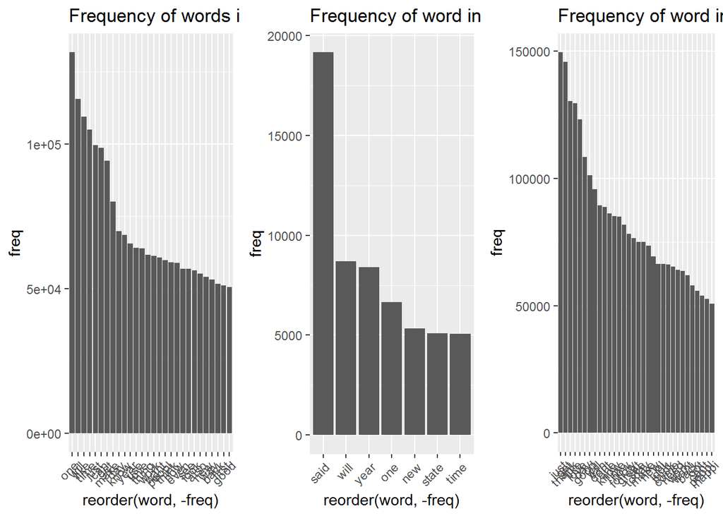

```r
wf_news <- data.frame(word=names(freq_news), freq=freq_news)
wf_twitter <- data.frame(word=names(freq_twitter), freq=freq_twitter)
library("ggplot2")

p_blogs <- ggplot(subset(wf_blogs, freq>50000), aes(x = reorder(word, -freq), y = freq)) +
          geom_bar(stat = "identity") + ggtitle("Frequency of words in blogs")+
          theme(axis.text.x=element_text(angle=45, hjust=1))
p_news <- ggplot(subset(wf_news, freq>5000), aes(x = reorder(word, -freq), y = freq)) +
          geom_bar(stat = "identity") + ggtitle("Frequency of word in news")+
          theme(axis.text.x=element_text(angle=45, hjust=1))
p_twitter <- ggplot(subset(wf_twitter, freq>50000), aes(x = reorder(word, -freq), y = freq)) +
          geom_bar(stat = "identity") +ggtitle("Frequency of word in twitter")+
          theme(axis.text.x=element_text(angle=45, hjust=1))
require(gridExtra)
grid.arrange(p_blogs,p_news,p_twitter, ncol= 3)
```

# Word Clouds

```r
require(RColorBrewer)
```

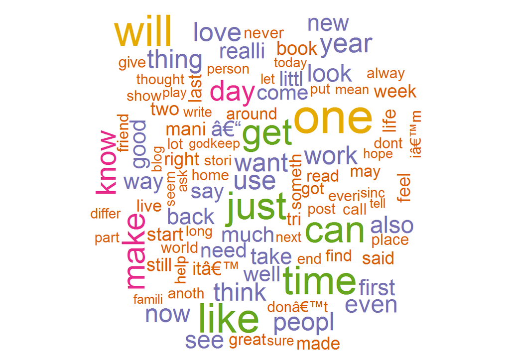

```r
#ploting the 100 most frequently occurring words in us_blogs
set.seed(142)
wordcloud::wordcloud(names(freq_blogs), freq_blogs, max.words=100, colors=brewer.pal(6, "Dark2"))
```

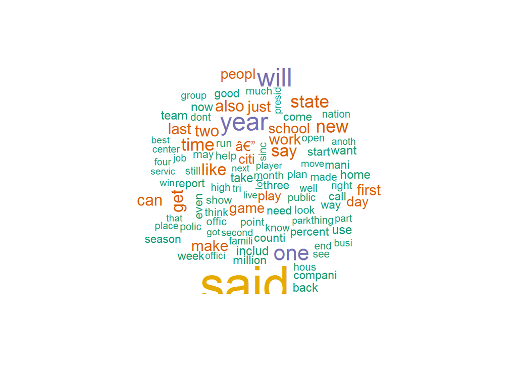

```r
#ploting the 100 most frequently occurring words in us_news
set.seed(142)
wordcloud::wordcloud(names(freq_news), freq_news, max.words=100, colors=brewer.pal(6, "Dark2"))
```

[figure not shown]

```r
#ploting the 100 most frequently occurring words in us_twitter
set.seed(142)
wordcloud::wordcloud(names(freq_twitter), freq_twitter, max.words=100, colors=brewer.pal(6, "Dark2"))
```

## Plans for Prediction Algorithm and Shiny App

The prediction algorithm will be based on the data used for this report.The data is cleaned to be lower case, without punctuation, numbers, or white space, stop and profanity words. The predictor will take the entered word or phrase (up to three previous words) and search the term document matrix of data for the most frequently used words following the queried word or phrase. It will then return the top five words ranked based on frequency. The Shiny app will utilize this predictor by having an input word so that a word or phrase may be entered and there will be five returned values as popular options for the next word in the phrase in order of likelihood.